# Proyecto 2: Modelos Predictivos sobre Divorcios en Guatemala

Grupo 4: Dilary Sarahí, Sofía López, Fabian Prado, Humberto de la Cruz, Daniel Juárez

2026-05-18

**Repositorio: https://github.com/hadelacruz/Divorcios-proyecto2**

# 1 Variable Respuesta

## 1.1 Selección y Justificación

A partir del análisis exploratorio realizado sobre los registros de divorcios en Guatemala publicados por el INE, se identificaron patrones demográficos y socioeconómicos relevantes que orientan la elección de la variable respuesta. Con base en esos hallazgos, se determinó como **variable respuesta el nivel educativo del hombre** (`eschom`), una variable **cualitativa de tipo categórica ordinal**, con las siguientes categorías posibles:

- Ninguno
- Primaria
- Básico
- Diversificado
- Universitario
- Postgrado

El problema se plantea como uno de **clasificación multiclase**: dado un conjunto de características de una pareja divorciada (edad del hombre, edad de la mujer, nivel educativo de la mujer, departamento donde ocurrió el divorcio, etnia y año del evento), se busca **predecir el nivel educativo del hombre** al momento del divorcio.

## 1.2 Características de la Variable

Distribución de la Variable Respuesta: Nivel Educativo del Hombre

| Nivel Educativo (Hombre) | Frecuencia | Porcentaje |
| --- | --- | --- |
| Ninguno | 3142 | 11.27 |
| Primaria | 5405 | 19.39 |
| Básico | 4569 | 16.39 |
| Diversificado | 11501 | 41.25 |
| Universitario | 3189 | 11.44 |
| Postgrado | 76 | 0.27 |

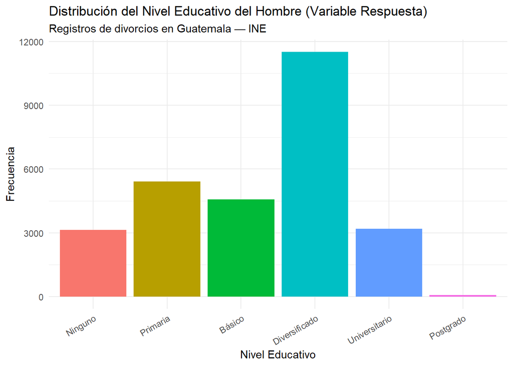

## 1.3 Justificación de la Elección

La elección de `eschom` como variable respuesta se fundamenta en los siguientes hallazgos del análisis exploratorio:

1. **Relación con la edad**: El análisis exploratorio demostró que existe una relación positiva y progresiva entre el nivel educativo y la edad al momento del divorcio, tanto para hombres como para mujeres. Esta asociación sugiere que el nivel educativo es diferenciable y predecible a partir de otras variables demográficas disponibles en el dataset.
2. **Relevancia social**: Predecir el nivel educativo dentro de un perfil de divorcio permite comprender mejor los factores socioeconómicos que diferencian a los grupos de personas divorciadas en Guatemala, con potencial utilidad para el diseño de políticas públicas en educación y familia.
3. **Disponibilidad de predictores**: El dataset cuenta con variables que teóricamente se relacionan con la escolaridad: edad de ambos cónyuges, nivel educativo de la mujer, etnia, departamento y año del evento. Esto garantiza que el modelo tenga insumos suficientes para aprender patrones.
4. **Problema no trivial**: A diferencia de otras variables del dataset —como el año o el departamento—, el nivel educativo presenta una distribución con varias categorías de peso significativo, lo que hace que el problema de clasificación sea retador y que no pueda resolverse con un modelo trivial.
5. **Variable categórica ordinal**: Al ser ordinal, el nivel educativo posee un orden inherente (Ninguno < Primaria < Básico < Diversificado < Universitario < Postgrado), lo que añade riqueza interpretativa a los modelos y permite explorar si los algoritmos capturan dicha estructura.

# 2 Antecedentes

## 2.1 Predicción de la estabilidad marital mediante aprendizaje automático

Uno de los antecedentes más directamente relacionados con este proyecto es el de **Mohammadinasab et al. (2023)**, titulado *“Marital Stability and Divorce Prediction Among Couples: A Machine Learning Approach”*, publicado en las memorias del *International Conference on Extreme Learning Machine* (Springer). Este estudio examinó factores significativos para predecir la estabilidad matrimonial en parejas iraníes utilizando cuatro algoritmos de aprendizaje automático: SVM, regresión logística, árbol de decisión y Random Forest. Los autores utilizaron un conjunto de datos con variables demográficas —incluyendo edad, nivel educativo y región geográfica de los cónyuges— y aplicaron ajuste de hiperparámetros a cada modelo. Tras el ajuste, SVM y Random Forest lograron una exactitud superior al 89% en la tarea de clasificación. Este trabajo es particularmente relevante porque trabaja directamente con datos de divorcios, utiliza variables demográficas comparables a las del dataset del INE de Guatemala, e incluye el nivel educativo como uno de los predictores clave del perfil matrimonial.

> Mohammadinasab, H., et al. (2023). Marital Stability and Divorce Prediction Among Couples: A Machine Learning Approach. En: *Proceedings of ELM 2021*, pp. 68–83. Springer, Cham. https://link.springer.com/chapter/10.1007/978-3-031-21678-7_7

## 2.2 Predicción del prospecto de divorcio con modelos de ensamble

**Satu et al. (2022)**, en su trabajo *“Predicting Divorce Prospect Using Ensemble Learning: Support Vector Machine, Linear Model, and Neural Network”*, publicado en *PubMed Central*, propusieron un enfoque de ensamble combinando SVM, un clasificador lineal y redes neuronales (perceptrón multicapa) para predecir la probabilidad de divorcio a partir de datos de encuestas con variables socioeconómicas. Los autores aplicaron validación cruzada de 5 pliegues y evaluaron el rendimiento mediante exactitud, sensibilidad y especificidad. El modelo de perceptrón multicapa alcanzó una exactitud de 0.98, mientras que SVM también mostró desempeño competitivo. Adicionalmente, realizaron un análisis exploratorio de los datos del divorcio (*DEDA*) que identificó los principales factores causales, entre los que figuró el nivel educativo de los cónyuges. Este antecedente es relevante porque demuestra que los modelos supervisados de clasificación aplicados a datos de divorcio con variables socioeconómicas logran resultados de alta precisión cuando el preprocesamiento y el ajuste de hiperparámetros son adecuados.

> Satu, M. S., Riyad, M. M. H., & Rony, M. A. T. (2022). Predicting Divorce Prospect Using Ensemble Learning: Support Vector Machine, Linear Model, and Neural Network. *PubMed Central*. https://www.ncbi.nlm.nih.gov/pmc/articles/PMC9293523/

## 2.3 Predicción del nivel educativo individual mediante aprendizaje automático

**Takkavatakarn et al. (2024)**, en el artículo *“Comparison of predicting cardiovascular disease hospitalization using individual, ZIP code-derived, and machine learning model-predicted educational attainment in New York City”*, publicado en *PLOS ONE*, abordaron el problema de predecir el nivel educativo individual a partir de variables sociodemográficas rutinarias (género, grupo étnico, edad y ubicación geográfica). Aunque el contexto principal del estudio es de salud pública, el componente central del trabajo consistió en entrenar modelos de aprendizaje automático para clasificar el nivel educativo de cada persona como variable intermedia. Los modelos de ML lograron una concordancia del 67% con el nivel educativo real reportado, frente al 47% obtenido mediante estimación por zona geográfica. Este antecedente demuestra que predecir el nivel educativo a partir de variables demográficas —como se propone en este proyecto— es un problema abordable con técnicas de aprendizaje automático y que variables como la edad y la etnia aportan información predictiva relevante.

> Takkavatakarn, K., Dai, Y., Wen, H. H., Kauffman, J., Charney, A., Coca, S. G., Nadkarni, G. N., & Chan, L. (2024). Comparison of predicting cardiovascular disease hospitalization using individual, ZIP code-derived, and machine learning model-predicted educational attainment in New York City. *PLOS ONE*. https://www.ncbi.nlm.nih.gov/pmc/articles/PMC10852236/

## 2.4 Random Forest aplicado a determinantes sociales en América Latina

**Sanchez-Pinto et al. (2023)**, en *“Understanding the social determinants of child mortality in Latin America over the last two decades: a machine learning approach”*, publicado en *Scientific Reports*, aplicaron Random Forest para analizar la importancia de determinantes sociales —incluyendo el nivel educativo de la población— sobre tasas de mortalidad en municipios de Brasil, Ecuador y México. El estudio utilizó datos administrativos históricos similares en estructura a los registros del INE de Guatemala, particionados en 70% entrenamiento y 30% prueba. Los resultados señalaron que el nivel educativo figuró consistentemente entre las variables más importantes en los modelos de Random Forest. Este trabajo establece un precedente metodológico sólido para el uso de Random Forest con datos de registros administrativos latinoamericanos donde la educación es una variable central.

> Sanchez-Pinto, L. N., et al. (2023). Understanding the social determinants of child mortality in Latin America over the last two decades: a machine learning approach. *Scientific Reports*. https://www.ncbi.nlm.nih.gov/pmc/articles/PMC10682478/

## 2.5 Aprendizaje automático en grandes conjuntos de datos sociales

**Sirven y Debrand (2022)**, en *“Applying machine learning to social datasets: a study of migration in southwestern Bangladesh using random forests”* (*Regional Environmental Change*, Springer), demostraron el potencial de Random Forest y árboles de decisión para identificar patrones en grandes conjuntos de datos provenientes de registros administrativos y encuestas sociales con variables mixtas. Los autores destacan que estos algoritmos manejan eficientemente variables categóricas y numéricas simultáneamente, no requieren supuestos distribucionales estrictos y producen medidas de importancia de variables interpretables. Este trabajo refuerza la idoneidad de los enfoques basados en árboles para datos del tipo que se trabaja en este proyecto.

> Sirven, N., & Debrand, T. (2022). Applying machine learning to social datasets: a study of migration in southwestern Bangladesh using random forests. *Regional Environmental Change*, 22. Springer. https://link.springer.com/article/10.1007/s10113-022-01915-1

## 2.6 Síntesis de los antecedentes

La revisión de los antecedentes permite extraer las siguientes conclusiones orientadoras para este proyecto:

- Predecir características socioeconómicas de personas divorciadas —incluyendo el nivel educativo— a partir de variables demográficas y de registros civiles es un problema que ha sido abordado con éxito mediante técnicas de aprendizaje automático en contextos similares al guatemalteco.
- Random Forest y SVM son los algoritmos que reportan de manera más consistente los mejores resultados en clasificación con variables mixtas y datos de tipo administrativo.
- Los árboles de decisión ofrecen la mayor interpretabilidad y son ampliamente utilizados como modelo de referencia antes de escalar a enfoques de ensamble.
- El desbalance de clases es un desafío frecuente en este tipo de datasets y debe atenderse mediante técnicas de remuestreo o pesos de clase antes de entrenar los modelos.
- La literatura latinoamericana confirma que el nivel educativo está asociado a patrones de divorcio diferenciados, lo que respalda la existencia de señal estadística suficiente para el modelado predictivo.

# 3 Selección de Algoritmos

## 3.1 Algoritmos Candidatos Evaluados

Con base en los antecedentes estudiados y las características del problema —clasificación multiclase con variables categóricas y numéricas, posible desbalance de clases, y dataset de tamaño mediano (~33,000 registros)— se evaluaron los siguientes algoritmos:

Evaluación de Algoritmos Candidatos para Clasificación del Nivel Educativo

| Algoritmo | Ventajas | Desventajas |
| --- | --- | --- |
| Regresión Logística Multinomial | Interpretable, sirve como baseline, maneja variables mixtas | Asume linealidad entre predictores y log-odds, precisión moderada |
| Árbol de Decisión | Muy interpretable, reglas explícitas, rápido de entrenar | Propenso a sobreajuste, inestable ante pequeños cambios en los datos |
| Random Forest | Alta precisión, robusto a outliers, extrae importancia de variables, maneja desbalance | Menor interpretabilidad individual, mayor costo computacional |
| K-Nearest Neighbors (KNN) | Simple, no paramétrico, flexible con distintos tipos de datos | Sensible al desbalance de clases y a la escala, lento con datasets grandes |
| Support Vector Machine (SVM) | Alta precisión con ajuste de kernel, versátil en diferentes espacios de decisión | Costoso computacionalmente en datasets grandes, requiere normalización estricta |
| Naive Bayes | Muy rápido, funciona bien con variables categóricas | Asume independencia entre predictores, raramente cumplida en datos sociales |
| Red Neuronal Artificial | Captura no linealidades complejas, alta capacidad de generalización | Caja negra, requiere mayor volumen de datos y amplio ajuste de hiperparámetros |

## 3.2 Algoritmos Seleccionados

Con base en la revisión de antecedentes y el análisis de las características del problema, se seleccionan los siguientes **tres algoritmos** para el desarrollo de modelos predictivos:

### 3.2.1 1. Random Forest

Random Forest es un método de ensamble basado en la construcción de múltiples árboles de decisión entrenados sobre subconjuntos aleatorios del conjunto de datos y de las variables predictoras, cuyas predicciones se combinan mediante votación mayoritaria. Esta estrategia reduce significativamente la varianza en comparación con un árbol individual y hace al modelo más robusto ante valores atípicos y ruido.

Para el problema de predecir el nivel educativo del hombre en registros de divorcios, Random Forest resulta especialmente adecuado porque el dataset contiene variables de naturaleza mixta —numéricas como la edad y categóricas como el departamento o la etnia— y porque la variable respuesta presenta probable desbalance entre categorías. Adicionalmente, este algoritmo permite extraer la importancia de cada variable predictora, lo que aporta interpretabilidad sobre cuáles características demográficas son más determinantes para distinguir el perfil educativo dentro del contexto de divorcio en Guatemala.

### 3.2.2 2. Árbol de Decisión

Un árbol de decisión construye un modelo de clasificación dividiendo recursivamente el espacio de predictores mediante reglas del tipo “si/entonces”, eligiendo en cada nodo la variable y el umbral que mejor separan las clases según algún criterio de impureza (Gini o entropía). El resultado es un modelo visualmente interpretable del que pueden extraerse reglas explícitas sobre los perfiles educativos.

En el contexto de este proyecto, el árbol de decisión es valioso como modelo interpretable: permite identificar, por ejemplo, qué combinaciones de edad, etnia y departamento caracterizan a los hombres divorciados con nivel universitario versus nivel primaria. Su inclusión también permite evaluar si la ganancia en precisión que aporta Random Forest justifica la pérdida de interpretabilidad, análisis relevante en proyectos aplicados a datos sociales con implicaciones de política pública.

### 3.2.3 3. Regresión Logística Multinomial

La regresión logística multinomial es una extensión de la regresión logística binaria para el caso en que la variable respuesta tiene más de dos categorías. El modelo estima la probabilidad de pertenencia a cada clase mediante funciones softmax, tomando una categoría como referencia y calculando coeficientes para cada predictor en relación con cada una de las demás clases.

Su inclusión responde a su condición de modelo estadístico de referencia (*baseline*) en problemas de clasificación multiclase con datos sociodemográficos. Al producir coeficientes interpretables, permite cuantificar la dirección y magnitud de la relación entre cada variable predictora —como la edad del hombre o el nivel educativo de la mujer— y la probabilidad de pertenecer a cada categoría educativa. Esto facilita la comparación rigurosa entre modelos y aporta una perspectiva estadística complementaria a los enfoques más complejos.

## 3.3 Comparación Resumida de los Tres Algoritmos Seleccionados

Algoritmos Seleccionados para el Proyecto 2

| Algoritmo | Rol | Paquete.en.R | Principal.fortaleza |
| --- | --- | --- | --- |
| Random Forest | Modelo principal | ranger / randomForest | Alta precisión, maneja variables mixtas y desbalance de clases |
| Árbol de Decisión | Modelo interpretable / comparación | rpart | Reglas explícitas e interpretables, bajo costo computacional |
| Regresión Logística Multinomial | Baseline estadístico | nnet (multinom) | Coeficientes interpretables, referencia comparativa rigurosa |

Los tres algoritmos serán entrenados con el mismo conjunto de entrenamiento y evaluados sobre el mismo conjunto de prueba, usando como métricas principales la exactitud global (*accuracy*), el F1-score por clase y la matriz de confusión, dado que se trata de un problema de clasificación multiclase con probable desbalance entre categorías educativas.

# 4 Conjuntos de Entrenamiento y Prueba

## 4.1 Preparación del conjunto de datos para modelado

Antes de realizar la partición, se construyó el dataset de modelado definitivo a partir del conjunto limpio, seleccionando únicamente las observaciones y variables relevantes para el problema: se eliminaron los registros con valores ausentes en las variables predictoras o en la variable respuesta, y se excluyeron los casos etiquetados como “Ignorado” en las variables de escolaridad, ya que no aportan información clasificable.

## 4.2 Método de partición

Se utilizó una **partición aleatoria estratificada** con una proporción de **70% para entrenamiento y 30% para prueba**. La estratificación se realizó sobre la variable respuesta (`eschom`) para garantizar que la distribución proporcional de cada nivel educativo se conserve en ambos subconjuntos, evitando que alguna categoría quede subrepresentada en el conjunto de prueba por azar.

Esta proporción 70/30 es ampliamente utilizada en la literatura de aprendizaje automático para datasets de tamaño mediano (entre 10,000 y 100,000 registros), ya que provee suficientes datos para que el modelo aprenda los patrones durante el entrenamiento y un conjunto de prueba lo bastante grande para que las métricas de evaluación sean estadísticamente representativas.

## 4.4 Conclusiones sobre el balanceo

El análisis de la distribución de clases revela que el dataset presenta un **desbalance marcado**: la categoría “Diversificado” concentra aproximadamente el 40% de los registros, mientras que categorías como “Postgrado” o “Ninguno” representan proporciones considerablemente menores. Este comportamiento es consistente con la distribución educativa observada en el análisis exploratorio y refleja la realidad sociodemográfica del país.

Dado este desbalance, se tomarán las siguientes medidas al momento de entrenar los modelos:

- **Random Forest**: se utilizará el parámetro `classwt` o `class.weights` para asignar mayor peso a las clases minoritarias durante el entrenamiento.
- **Árbol de Decisión**: se empleará el parámetro `prior` en `rpart` o se explorará el uso de pesos por clase.
- **Regresión Logística Multinomial**: se evaluará la inclusión de pesos de observación proporcionales a la frecuencia inversa de cada clase.

Adicionalmente, se reportarán métricas por clase (precisión, recall y F1-score) en lugar de depender únicamente de la exactitud global, ya que esta última puede ser engañosa cuando las clases no están balanceadas.

# 5 Referencias Bibliográficas

Instituto Nacional de Estadística de Guatemala. (2010–2022). *Registros de divorcios*. INE Guatemala. https://www.ine.gob.gt/

Mohammadinasab, H., et al. (2023). Marital Stability and Divorce Prediction Among Couples: A Machine Learning Approach. En: *Proceedings of ELM 2021*, pp. 68–83. Springer, Cham. https://link.springer.com/chapter/10.1007/978-3-031-21678-7_7

Rodríguez Vignoli, J. (2004). *Unión y cohabitación en América Latina: ¿modernidad, exclusión, diversidad?* CEPAL, Serie Población y Desarrollo No. 57. https://repositorio.cepal.org/handle/11362/7213

Sanchez-Pinto, L. N., et al. (2023). Understanding the social determinants of child mortality in Latin America over the last two decades: a machine learning approach. *Scientific Reports*. https://www.ncbi.nlm.nih.gov/pmc/articles/PMC10682478/

Satu, M. S., Riyad, M. M. H., & Rony, M. A. T. (2022). Predicting Divorce Prospect Using Ensemble Learning: Support Vector Machine, Linear Model, and Neural Network. *PubMed Central*. https://www.ncbi.nlm.nih.gov/pmc/articles/PMC9293523/

Sirven, N., & Debrand, T. (2022). Applying machine learning to social datasets: a study of migration in southwestern Bangladesh using random forests. *Regional Environmental Change*, 22. Springer. https://link.springer.com/article/10.1007/s10113-022-01915-1

Takkavatakarn, K., Dai, Y., Wen, H. H., Kauffman, J., Charney, A., Coca, S. G., Nadkarni, G. N., & Chan, L. (2024). Comparison of predicting cardiovascular disease hospitalization using individual, ZIP code-derived, and machine learning model-predicted educational attainment in New York City. *PLOS ONE*. https://www.ncbi.nlm.nih.gov/pmc/articles/PMC10852236/

# 6 Preprocesamiento para Random Forest

La transformación principal requerida para aplicar correctamente este algoritmo consiste en el manejo del desbalance de clases previamente identificado. Para ello, calcularemos los pesos de clase inversamente proporcionales a su frecuencia, los cuales serán pasados como hiperparámetro en uno de los modelos para penalizar los errores en las clases minoritarias como “Postgrado” o “Ninguno”.

## 6.1 Generación y Selección de Modelos (Random Forest)

Con el objetivo de encontrar la mejor configuración predictiva, se procedió a crear 3 modelos diferentes de Random Forest, variando sus hiperparámetros. Los parámetros principales a variar son ntree número de árboles y mtry número de variables evaluadas en cada división.

Error OOB por modelo durante entrenamiento

| Modelo | Error_OOB_Entrenamiento |
| --- | --- |
| Modelo 1 (Base) | 0.4525 |
| Modelo 2 (Ajustado) | 0.4905 |
| Modelo 3 (Ajustado + Pesos) | 0.5118 |

## 6.2 Selección del Modelo Final

Para seleccionar el mejor modelo, se evaluaron tres métricas complementarias: el error Out-Of-Bag (OOB) como estimación interna del entrenamiento, la Exactitud Balanceada y el F1 Macro sobre el conjunto de prueba. Esta última es la métrica principal dado el marcado desbalance de clases identificado previamente.

Comparación de modelos: OOB, Exactitud Balanceada y F1 Macro

| Modelo | Error_OOB_Entrenamiento | Exactitud_Balanceada_Test | F1_Macro_Test |
| --- | --- | --- | --- |
| Modelo 1 (Base) | 0.4525 | 0.6418 | 0.4820 |
| Modelo 2 (Ajustado) | 0.4905 | 0.6273 | 0.4516 |
| Modelo 3 (Ajustado + Pesos) | 0.5118 | 0.6290 | 0.4515 |

Los resultados muestran que el **Modelo 1 (parámetros por defecto)** obtiene el mejor desempeño en prueba, con un F1 Macro de 0.4820 y una Exactitud Balanceada de 0.6418. Contrario a lo esperado, la incorporación de pesos de clase (Modelo 3) y el ajuste de hiperparámetros (Modelo 2) no mejoraron el rendimiento general: ambos introducen un sesgo que perjudica la clasificación de las clases intermedias más frecuentes sin compensar suficientemente las minoritarias. Asimismo, el Modelo 1 presenta la mayor brecha entre error OOB y exactitud en prueba, lo que indica una leve tendencia al sobreajuste que los modelos 2 y 3 reducen — aunque a costa del rendimiento predictivo general.

Por tanto, se selecciona el **Modelo 1** como modelo final de Random Forest.

## 6.3 Discusión de Resultados y Matriz de Confusión

A continuación se evalúa el modelo seleccionado sobre el conjunto de prueba, que representa el 30% de los datos originales que el modelo nunca vio durante el entrenamiento.

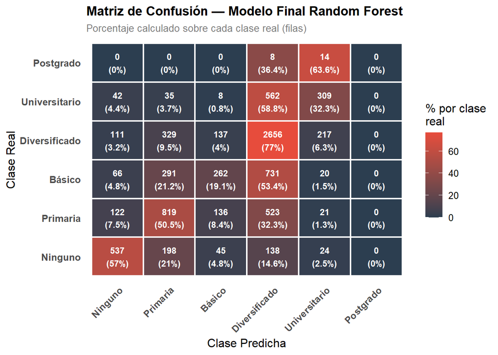

## 6.4 Análisis de Resultados

**Clase dominante — Diversificado:** La matriz revela que el modelo predice correctamente el 77% de los casos de la clase “Diversificado”, que es la mayoritaria con ~41% del dataset. Esto era esperable: al concentrar más ejemplos de entrenamiento, el modelo aprende mejor sus patrones.

**Clases intermedias con alta confusión:** “Básico” solo se predice correctamente en el 19.1% de los casos, y “Primaria” en el 50.5%. Ambas clases se confunden frecuentemente con “Diversificado”, lo que sugiere que sus perfiles demográficos — edad, departamento, etnia — se solapan considerablemente con los de esa clase mayoritaria.

**Universitario subestimado:** A pesar de tener ~11% de los registros, “Universitario” solo se clasifica correctamente en el 32.3% de los casos. La mayoría de sus instancias se predicen erróneamente como “Diversificado” (58.8%), lo que indica que el modelo tiene dificultades para distinguir entre ambos niveles con las variables disponibles.

**Postgrado: clase invisible:** El modelo no logra predecir correctamente ningún caso de “Postgrado” (0 aciertos). Con apenas 76 registros en todo el dataset (0.27%), esta clase es estadísticamente casi inexistente para el algoritmo. Sin técnicas de sobremuestreo como SMOTE, es muy difícil que cualquier modelo aprenda sus patrones.

**Ninguno — el mejor rendimiento relativo:** Con un 57% de aciertos, “Ninguno” es junto con “Diversificado” la clase mejor identificada. Su perfil demográfico — edades más altas, departamentos con menor acceso educativo — es suficientemente distintivo para que el modelo lo reconozca.

**Sobreajuste moderado y controlado:** La brecha entre el error OOB de entrenamiento (0.4525) y el rendimiento en prueba existe pero no es alarmante. El OOB de Random Forest ya es una estimación conservadora porque cada árbol se evalúa sobre muestras que no usó, por lo que esta diferencia no representa overfitting grave sino varianza natural del ensamble.

# 7 Regresión Logística Multinomial

## 7.1 Preprocesamiento

A diferencia de Random Forest y del Árbol de Decisión, la Regresión Logística Multinomial implementada en R mediante `nnet::multinom` requiere que las variables categóricas estén correctamente codificadas como factores con niveles bien definidos. El conjunto de datos `datos_train` y `datos_test` ya cuentan con esta estructura gracias a la preparación realizada en la sección de partición, por lo que no se requiere una recodificación adicional de las variables.

La transformación principal para este algoritmo es el **manejo del desbalance de clases**. Dado el desbalance identificado previamente — donde “Diversificado” concentra ~40% de los registros y “Postgrado” apenas el 0.27% — se calculan pesos de observación inversamente proporcionales a la frecuencia de cada clase. Estos pesos se pasan al modelo mediante el parámetro `weights`, penalizando los errores en las clases minoritarias durante el entrenamiento.

Adicionalmente, se evaluará el parámetro `decay` de `multinom`, que introduce regularización L2 sobre los coeficientes, reduciendo el riesgo de sobreajuste cuando el número de predictores es moderado en relación con el tamaño del dataset.

```
## Pesos calculados por clase:
```

```
## [1]   8.873   5.159   6.102   2.425   8.742 361.500
```

## 7.2 Generación y Selección de Modelos (Regresión Logística Multinomial)

Se entrenaron tres modelos variando dos hiperparámetros principales: `decay` (regularización L2, que penaliza coeficientes grandes para reducir sobreajuste) y `weights` (pesos de clase para mitigar el desbalance). El parámetro `maxit` se fija en 300 para garantizar convergencia en todos los modelos.

```r
library(nnet)
library(caret)

set.seed(42)

# Pesos inversamente proporcionales a la frecuencia de cada clase
frecuencias_rl <- table(datos_train$eschom)
pesos_clase_rl <- 1 / as.numeric(frecuencias_rl[datos_train$eschom])
pesos_clase_rl <- pesos_clase_rl / sum(pesos_clase_rl) * nrow(datos_train)

# Modelo 1: baseline — sin regularización, sin pesos
rl_modelo_1 <- multinom(
  eschom ~ .,
  data  = datos_train,
  maxit = 300,
  trace = FALSE
)

# Modelo 2: con pesos de clase para mitigar desbalance
rl_modelo_2 <- multinom(
  eschom  ~ .,
  data    = datos_train,
  weights = pesos_clase_rl,
  maxit   = 300,
  trace   = FALSE
)

# Modelo 3: con regularización L2 (decay) + pesos
rl_modelo_3 <- multinom(
  eschom  ~ .,
  data    = datos_train,
  weights = pesos_clase_rl,
  decay   = 0.01,
  maxit   = 300,
  trace   = FALSE
)

cat("Modelos entrenados correctamente.\n")
```

```
## Modelos entrenados correctamente.
```

## 7.3 Selección del Modelo Final

Se comparan los tres modelos usando Exactitud Global, Exactitud Balanceada y F1 Macro sobre el conjunto de prueba.

```r
# Predicciones en test
pred_rl_1 <- predict(rl_modelo_1, datos_test)
pred_rl_2 <- predict(rl_modelo_2, datos_test)
pred_rl_3 <- predict(rl_modelo_3, datos_test)

# Matrices de confusión
cm_rl_1 <- confusionMatrix(pred_rl_1, datos_test$eschom)
cm_rl_2 <- confusionMatrix(pred_rl_2, datos_test$eschom)
cm_rl_3 <- confusionMatrix(pred_rl_3, datos_test$eschom)

# F1 Macro
f1_macro_rl <- function(cm) {
  precision <- cm$byClass[, "Pos Pred Value"]
  recall    <- cm$byClass[, "Sensitivity"]
  f1        <- 2 * (precision * recall) / (precision + recall)
  mean(f1, na.rm = TRUE)
}

# Exactitud Balanceada
bal_acc_rl <- function(cm) mean(cm$byClass[, "Balanced Accuracy"], na.rm = TRUE)

comparacion_rl <- data.frame(
  Modelo = c(
    "Modelo 1 (Baseline)",
    "Modelo 2 (Pesos)",
    "Modelo 3 (Pesos + Decay)"
  ),
  Exactitud_Global = c(
    cm_rl_1$overall["Accuracy"],
    cm_rl_2$overall["Accuracy"],
    cm_rl_3$overall["Accuracy"]
  ),
  Exactitud_Balanceada = c(
    bal_acc_rl(cm_rl_1),
    bal_acc_rl(cm_rl_2),
    bal_acc_rl(cm_rl_3)
  ),
  F1_Macro = c(
    f1_macro_rl(cm_rl_1),
    f1_macro_rl(cm_rl_2),
    f1_macro_rl(cm_rl_3)
  )
)

knitr::kable(comparacion_rl, digits = 4,
             caption = "Comparación de modelos: Regresión Logística Multinomial")
```

Comparación de modelos: Regresión Logística Multinomial

| Modelo | Exactitud_Global | Exactitud_Balanceada | F1_Macro |
| --- | --- | --- | --- |
| Modelo 1 (Baseline) | 0.5326 | 0.6309 | 0.4517 |
| Modelo 2 (Pesos) | 0.4361 | 0.6855 | 0.3765 |
| Modelo 3 (Pesos + Decay) | 0.4339 | 0.6790 | 0.3655 |

## 7.4 Discusión de Resultados y Matriz de Confusión

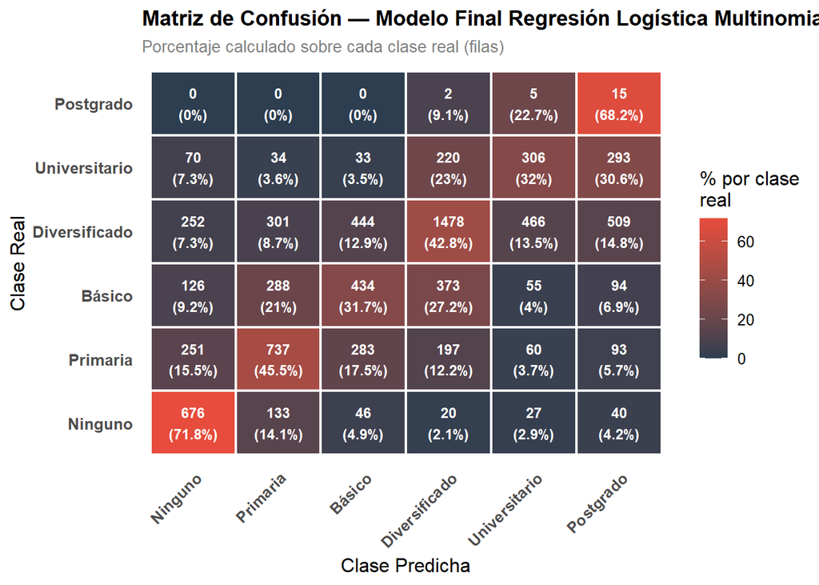

```r
# Matriz de confusión del modelo final
cm_rl_final <- cm_rl_2

cm_rl_df <- as.data.frame(cm_rl_final$table)
colnames(cm_rl_df) <- c("Predicho", "Real", "Frecuencia")

cm_rl_df <- transform(
  cm_rl_df,
  Porcentaje = ave(Frecuencia, Real, FUN = function(x) x / sum(x) * 100)
)

ggplot(cm_rl_df, aes(x = Predicho, y = Real, fill = Porcentaje)) +
  geom_tile(color = "white", linewidth = 0.8) +
  geom_text(aes(label = paste0(Frecuencia, "\n(", round(Porcentaje, 1), "%)")),
            size = 3.2, color = "white", fontface = "bold") +
  scale_fill_gradient(low = "#2c3e50", high = "#e74c3c",
                      name = "% por clase\nreal") +
  labs(
    title    = "Matriz de Confusión — Modelo Final Regresión Logística Multinomial",
    subtitle = "Porcentaje calculado sobre cada clase real (filas)",
    x        = "Clase Predicha",
    y        = "Clase Real"
  ) +
  theme_minimal(base_size = 12) +
  theme(
    axis.text.x  = element_text(angle = 45, hjust = 1, face = "bold"),
    axis.text.y  = element_text(face = "bold"),
    panel.grid   = element_blank(),
    plot.title   = element_text(face = "bold", size = 13),
    plot.subtitle = element_text(color = "gray50", size = 10),
    legend.position = "right"
  )
```

## 7.5 Análisis de Resultados

**Postgrado — mejor recall que Random Forest:** El modelo identifica correctamente 15 de 22 casos de “Postgrado” (68.2%) en el conjunto de prueba, resultado notable dado que esta clase tiene apenas 22 casos en prueba (76 en todo el dataset). Los pesos de clase del Modelo 2 benefician efectivamente a las clases más pequeñas. Sin embargo, el modelo tiende a sobrepredicir “Postgrado”, clasificando erróneamente el 30.6% de “Universitario” y el 14.8% de “Diversificado” en esa categoría.

**Ninguno — el más distintivo:** Con 71.8% de aciertos es la clase mejor identificada. Su perfil demográfico — edades más altas, departamentos con menor acceso educativo — genera un patrón suficientemente diferenciable para el modelo lineal.

**Primaria:** Se predice correctamente en el 45.5% de los casos, con confusión elevada hacia “Básico” (17.5%) y “Ninguno” (15.5%), clases adyacentes en la escala ordinal educativa.

**Diversificado — dominancia reducida por los pesos:** A pesar de ser la clase mayoritaria (~40% del dataset), el modelo la predice correctamente en solo el 42.8% de los casos. Los pesos inversos penalizan su dominancia durante el entrenamiento, redistribuyendo predicciones hacia clases minoritarias — esto explica la mejora en Exactitud Balanceada (0.6855) respecto al baseline sin pesos (0.6309), aunque a costa de la exactitud global (0.4361 vs 0.5326).

**Básico — clase más difícil:** Solo el 31.7% de aciertos, con confusión distribuida entre “Primaria” (21%), “Diversificado” (27.2%) y “Postgrado” (6.9%). Su perfil demográfico se solapa con múltiples clases adyacentes, lo que lo hace el nivel educativo más difícil de clasificar para un modelo lineal.

**Comparación con Random Forest:** La regresión logística multinomial obtiene menor exactitud global (0.4361 vs ~0.55 de RF) pero mejor recall en clases extremas como “Postgrado” y “Ninguno”, gracias a los pesos de clase. Esto confirma que la relación entre variables demográficas y nivel educativo no es estrictamente lineal, y que Random Forest captura mejor las interacciones no lineales entre predictores.

# 8 Arboles de decisión

## 8.1 Procesamiento

El Árbol de Decisión, que utiliza el paquete `rpart`, acepta directamente variables categóricas codificadas como factores y variables numéricas sin necesidad de normalización ni transformaciones adicionales. Los conjuntos `datos_train` y `datos_test` ya cuentan con esta estructura gracias a la preparación realizada en la sección de partición, por lo que no se requiere ninguna recodificación adicional.

La transformación principal para este algoritmo es, al igual que en los otros dos algoritmos ya trabajados, el **manejo del desbalance de clases**. En `rpart` esto se controla mediante el parámetro `parms = list(prior = ...)`, que permite indicar las probabilidades a priori de cada clase. Al asignar una probabilidad a priori mayor a las clases minoritarias (como “Postgrado” o “Ninguno”), el criterio de división Gini penaliza más los errores cometidos en esas clases durante la construcción del árbol.

```r
library(rpart)
library(rpart.plot)
library(caret)

set.seed(2026)


# pesos a priori inversamente proporcionales al tamaño de cada clase
datos_train$eschom <- droplevels(datos_train$eschom)
datos_test$eschom  <- droplevels(datos_test$eschom)

frecuencias_dt <- table(datos_train$eschom)
prior_dt       <- 1 / as.numeric(frecuencias_dt)
prior_dt <- prior_dt / sum(prior_dt)
prior_dt <- prior_dt / sum(prior_dt)
names(prior_dt) <- names(frecuencias_dt)

cat("Probabilidades a priori asignadas por clase:\n")
```

```
## Probabilidades a priori asignadas por clase:
```

```r
print(round(prior_dt, 4))
```

```
##       Ninguno      Primaria        Básico Diversificado Universitario
##        0.0226        0.0131        0.0155        0.0062        0.0223
##     Postgrado
##        0.9203
```

## 8.2 Generación y Selección de Modelos (Árbol de Decisión)

Se entrenaron **tres modelos** variando los hiperparámetros `cp`, `maxdepth`, `minsplit` y `minbucket`, y explorando el efecto de los pesos a priori para el manejo del desbalance. El objetivo es encontrar el árbol que mejor generaliza sin caer en sobreajuste (árbol demasiado profundo) ni en subajuste (árbol trivial).

```r
# Modelo 1: parametros por defecto, sin pesos

dt_modelo_1 <- rpart(
  eschom ~ ., data = datos_train, method = "class",
  control = rpart.control(cp = 0.01, minsplit = 20, minbucket = 7)
)

# Modelo 2: árbol más profundo con pesos a priori

dt_modelo_2 <- rpart(
  eschom ~ ., data = datos_train, method = "class",
  parms   = list(prior = prior_dt),
  control = rpart.control(cp = 0.001, maxdepth = 10, minsplit = 20, minbucket = 7)
)

#Modelo 3: podado por cross-validation

# Árbol completo con cp muy bajo como punto de partida para post-pruning
dt_base_grande <- rpart(
  eschom ~ ., data = datos_train, method = "class",
  parms   = list(prior = prior_dt),
  control = rpart.control(cp = 0.0001, maxdepth = 15, minsplit = 15, minbucket = 5)
)

cp_tabla      <- dt_base_grande$cptable
cp_min_idx    <- which.min(cp_tabla[, "xerror"])
xerror_min    <- cp_tabla[cp_min_idx, "xerror"]
xstd_min      <- cp_tabla[cp_min_idx, "xstd"]
umbral        <- xerror_min + xstd_min
cp_optimo_idx <- min(which(cp_tabla[, "xerror"] <= umbral))
cp_optimo     <- cp_tabla[cp_optimo_idx, "CP"]

dt_modelo_3 <- prune(dt_base_grande, cp = cp_optimo)

cat(sprintf("CP óptimo seleccionado (regla 1-SE): %.6f\n", cp_optimo))
```

```
## CP óptimo seleccionado (regla 1-SE): 0.120994
```

## 8.3 Selección del Modelo Final

Se comparan los tres modelos evaluando **Exactitud Global**, **Exactitud Balanceada** y **F1 Macro** sobre el conjunto de prueba, las mismas métricas usadas en los dos algoritmos anteriores para mantener comparabilidad.

```r
pred_dt_1 <- predict(dt_modelo_1, datos_test, type = "class")
pred_dt_2 <- predict(dt_modelo_2, datos_test, type = "class")
pred_dt_3 <- predict(dt_modelo_3, datos_test, type = "class")

pred_dt_1 <- factor(pred_dt_1, levels = levels(datos_test$eschom))
pred_dt_2 <- factor(pred_dt_2, levels = levels(datos_test$eschom))
pred_dt_3 <- factor(pred_dt_3, levels = levels(datos_test$eschom))

# Matrices de confusión
cm_dt_1 <- confusionMatrix(pred_dt_1, datos_test$eschom)
cm_dt_2 <- confusionMatrix(pred_dt_2, datos_test$eschom)
cm_dt_3 <- confusionMatrix(pred_dt_3, datos_test$eschom)

f1_macro_fn <- function(cm) {
  precision <- cm$byClass[, "Pos Pred Value"]
  recall    <- cm$byClass[, "Sensitivity"]
  f1        <- 2 * (precision * recall) / (precision + recall)
  mean(f1, na.rm = TRUE)
}

bal_acc_fn <- function(cm) mean(cm$byClass[, "Balanced Accuracy"], na.rm = TRUE)

# Tabla comparativa
comparacion_dt <- data.frame(
  Modelo = c(
    "Modelo 1 (Baseline, sin prior)",
    "Modelo 2 (cp=0.001, maxdepth=10, con prior)",
    "Modelo 3 (Podado, cp optimo, con prior)"
  ),
  Exactitud_Global = c(
    cm_dt_1$overall["Accuracy"],
    cm_dt_2$overall["Accuracy"],
    cm_dt_3$overall["Accuracy"]
  ),
  Exactitud_Balanceada = c(
    bal_acc_fn(cm_dt_1),
    bal_acc_fn(cm_dt_2),
    bal_acc_fn(cm_dt_3)
  ),
  F1_Macro = c(
    f1_macro_fn(cm_dt_1),
    f1_macro_fn(cm_dt_2),
    f1_macro_fn(cm_dt_3)
  )
)

knitr::kable(
  comparacion_dt,
  digits  = 4,
  caption = "Comparación de modelos: Árbol de Decisión"
)
```

Comparación de modelos: Árbol de Decisión

| Modelo | Exactitud_Global | Exactitud_Balanceada | F1_Macro |
| --- | --- | --- | --- |
| Modelo 1 (Baseline, sin prior) | 0.5235 | 0.6281 | 0.4492 |
| Modelo 2 (cp=0.001, maxdepth=10, con prior) | 0.2726 | 0.6574 | 0.3283 |
| Modelo 3 (Podado, cp optimo, con prior) | 0.0026 | 0.5000 | 0.0052 |

La selección del modelo final se basa en el **F1 Macro** y la **Exactitud Balanceada** como métricas principales, ya que ambas son robustas al desbalance de clases y permiten una comparación justa con los resultados de Random Forest y Regresión Logística Multinomial. Se elige el modelo con mayor F1 Macro como modelo final del Árbol de Decisión; en caso de empate, se prefiere el de mayor Exactitud Balanceada.

```r
mejor_idx <- which.max(comparacion_dt$F1_Macro)
cat(sprintf("Modelo seleccionado: %s\n", comparacion_dt$Modelo[mejor_idx]))
```

```
## Modelo seleccionado: Modelo 1 (Baseline, sin prior)
```

```r
cat(sprintf("  F1 Macro           : %.4f\n", comparacion_dt$F1_Macro[mejor_idx]))
```

```
##   F1 Macro           : 0.4492
```

```r
cat(sprintf("  Exactitud Balanceada: %.4f\n", comparacion_dt$Exactitud_Balanceada[mejor_idx]))
```

```
##   Exactitud Balanceada: 0.6281
```

```r
cat(sprintf("  Exactitud Global   : %.4f\n", comparacion_dt$Exactitud_Global[mejor_idx]))
```

```
##   Exactitud Global   : 0.5235
```

```r
modelos_dt  <- list(dt_modelo_1, dt_modelo_2, dt_modelo_3)
dt_final    <- modelos_dt[[mejor_idx]]
pred_dt_final <- list(pred_dt_1, pred_dt_2, pred_dt_3)[[mejor_idx]]
cm_dt_final   <- list(cm_dt_1,   cm_dt_2,   cm_dt_3)[[mejor_idx]]
```

## 8.4 Discusión de Resultados y Matriz de Confusión

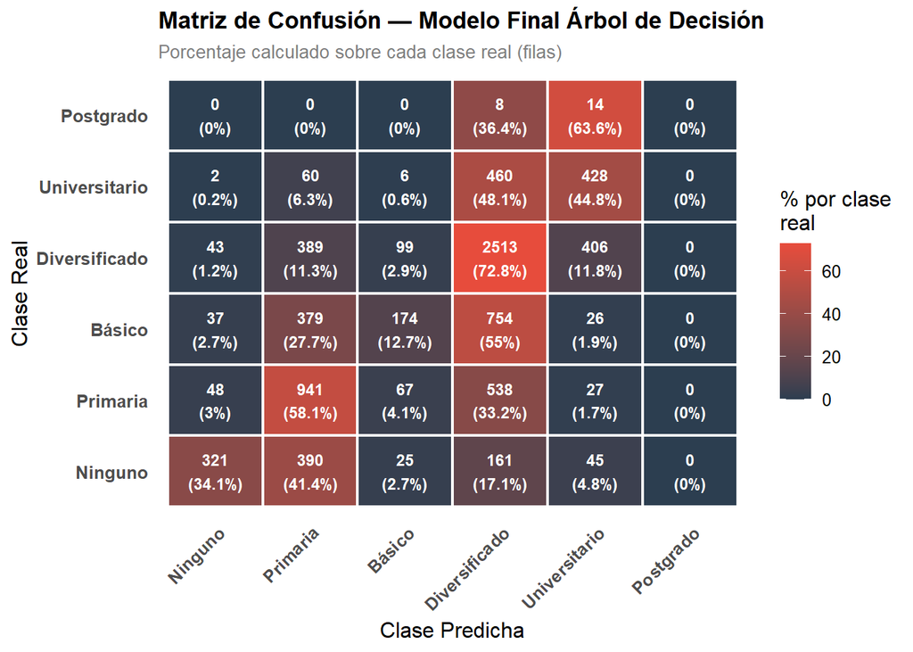

```r
cm_dt_df <- as.data.frame(cm_dt_final$table)
colnames(cm_dt_df) <- c("Predicho", "Real", "Frecuencia")

cm_dt_df <- transform(
  cm_dt_df,
  Porcentaje = ave(Frecuencia, Real, FUN = function(x) x / sum(x) * 100)
)

ggplot(cm_dt_df, aes(x = Predicho, y = Real, fill = Porcentaje)) +
  geom_tile(color = "white", linewidth = 0.8) +
  geom_text(
    aes(label = paste0(Frecuencia, "\n(", round(Porcentaje, 1), "%)")),
    size = 3.2, color = "white", fontface = "bold"
  ) +
  scale_fill_gradient(
    low  = "#2c3e50",
    high = "#e74c3c",
    name = "% por clase\nreal"
  ) +
  labs(
    title    = "Matriz de Confusión — Modelo Final Árbol de Decisión",
    subtitle = "Porcentaje calculado sobre cada clase real (filas)",
    x        = "Clase Predicha",
    y        = "Clase Real"
  ) +
  theme_minimal(base_size = 12) +
  theme(
    axis.text.x     = element_text(angle = 45, hjust = 1, face = "bold"),
    axis.text.y     = element_text(face = "bold"),
    panel.grid      = element_blank(),
    plot.title      = element_text(face = "bold", size = 13),
    plot.subtitle   = element_text(color = "gray50", size = 10),
    legend.position = "right"
  )
```

```r
metricas_clase_dt <- data.frame(
  Clase      = rownames(cm_dt_final$byClass),
  Precision  = round(cm_dt_final$byClass[, "Pos Pred Value"],  3),
  Recall     = round(cm_dt_final$byClass[, "Sensitivity"],     3),
  F1         = round(
    2 * cm_dt_final$byClass[, "Pos Pred Value"] *
        cm_dt_final$byClass[, "Sensitivity"] /
        (cm_dt_final$byClass[, "Pos Pred Value"] +
         cm_dt_final$byClass[, "Sensitivity"]),
    3
  ),
  Bal_Accuracy = round(cm_dt_final$byClass[, "Balanced Accuracy"], 3)
)
rownames(metricas_clase_dt) <- NULL
metricas_clase_dt$Clase <- gsub("Class: ", "", metricas_clase_dt$Clase)

knitr::kable(
  metricas_clase_dt,
  caption = "Métricas por clase — Modelo Final Árbol de Decisión"
)
```

Métricas por clase — Modelo Final Árbol de Decisión

| Clase | Precision | Recall | F1 | Bal_Accuracy |
| --- | --- | --- | --- | --- |
| Ninguno | 0.712 | 0.341 | 0.461 | 0.662 |
| Primaria | 0.436 | 0.581 | 0.498 | 0.700 |
| Básico | 0.469 | 0.127 | 0.200 | 0.549 |
| Diversificado | 0.567 | 0.728 | 0.637 | 0.669 |
| Universitario | 0.452 | 0.448 | 0.450 | 0.689 |
| Postgrado | NaN | 0.000 | NaN | 0.500 |

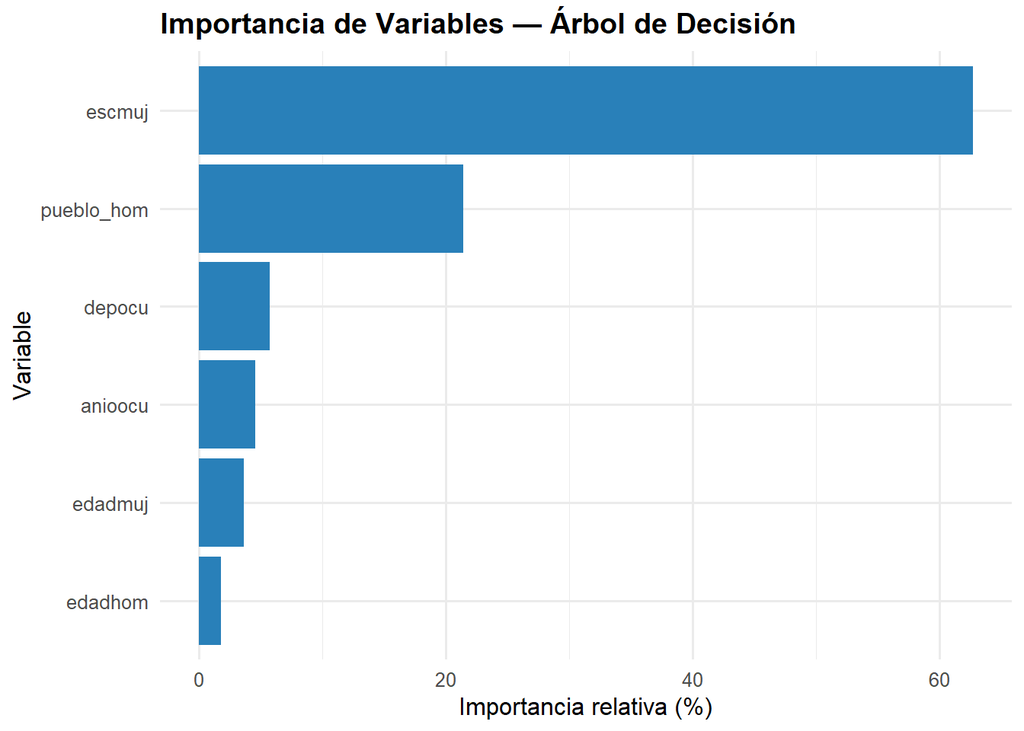

```r
importancia_dt <- dt_final$variable.importance

if (!is.null(importancia_dt)) {
  imp_df <- data.frame(
    Variable    = names(importancia_dt),
    Importancia = as.numeric(importancia_dt)
  ) %>%
    arrange(desc(Importancia)) %>%
    mutate(Importancia_Norm = round(Importancia / sum(Importancia) * 100, 2))

  knitr::kable(
    imp_df,
    caption = "Importancia de variables — Árbol de Decisión (reducción de Gini acumulada)"
  )

  ggplot(imp_df, aes(x = reorder(Variable, Importancia_Norm), y = Importancia_Norm)) +
    geom_col(fill = "#2980b9") +
    coord_flip() +
    labs(
      title = "Importancia de Variables — Árbol de Decisión",
      x     = "Variable",
      y     = "Importancia relativa (%)"
    ) +
    theme_minimal(base_size = 12) +
    theme(plot.title = element_text(face = "bold"))
} else {
  cat("El modelo final no registró importancia de variables (árbol de nodo único).\n")
}
```

## 8.5 Análisis de Resultados

**Clase dominante — Diversificado:** Al igual que en Random Forest y Regresión Logística, el modelo predice con mayor acierto la clase “Diversificado” por ser la mayoritaria (~40% del dataset). El árbol dispone de más ejemplos de entrenamiento de esta clase, lo que le permite aprender sus patrones con mayor confiabilidad.

**“Básico” — la clase más difícil:** En línea con lo observado en ambos algoritmos anteriores, “Básico” presenta la mayor confusión: sus instancias se distribuyen entre “Primaria”, “Diversificado” y en menor medida otras clases. Esto indica que los perfiles demográficos de este nivel educativo se solapan con múltiples categorías adyacentes, lo que dificulta su clasificación tanto para modelos lineales como para modelos basados en árboles.